# The Analysis of Disney Stock with Respect to Movies Releases

Carly Mahoney

05/14/2021

## Abstract

Long term, it is easy to see that Disney stock has seen exponential increase, but what effects it short term is more of a mystery. This project tried to identify the possible effects movie releases and Disney parks events have on short term stock price changes. ANOVA was used to determine if the category of movie that is released causes different changes in Disney’s stock the week leading up to, the week after, and the day of an event. T-tests were used to compared movie release stock changes before the year 2000 to after the year 2000 and to compare percent change in stock the week before a release to the week after a release. Confidence intervals were also examined to explore overall stock change averages. It was hypothesized that movie categories that are believed to be more popular such as Marvel movies, would have more of an effect on short term stocks prices. Because movie production was Disney’s main area of expertise before the year 2000 it was also hypothesized that movie releases would have more of an effect on stock before 2000 vs after 2000. No evidence was found to prove either of the hypotheses, however there were a couple confidence intervals that suggested a positive percent change in stock price in the week leading up to a release. More analysis is needed to determine if this can be contributed to movie releases and to find other possible sources for short term Disney stock changes.

## Introduction

Often times, when people hear Disney, the first thing they think of is Disney World or Disney movies. Although they are known for animation, Disney creates many categories of movies. This project looks to explore the short term effects different categories of movie releases and Disney parks events have on Disney stock prices the week after a release, the week before a release, and the day of a release. It also determines if there is a difference in how movie releases affected stock prices before the year 2000 and after the year 2000.

I hypothesize the stock prices will increase differently depending on the category of movie that is released. Since in recent years Marvel movies have done really well at the box office, I would guess the Marvel category will have the largest increase in stock price the week after a premiere. I also think There will be a significant difference between changes in stock prices before 2000 and after 2000. After the turn of the century, Disney started acquiring more assets. They purchased Marvel and Star Wars, launched Disney Plus, purchased ABC, the History channel, and ESPN, launched a full fleet of cruise ships, etc. Now that Disney is way more than just theme parks and movies, I hypothesize that a movie release before the year 2000 had more of an effect on the stock prices because movies were the basis of the company.

I order to test my hypotheses, I will use one-way ANOVA and t-tests. One-way ANOVA will be used to determine whether different types of movie releases and events have different different short term effects on stock and t-tests will be used to determine if movie releases had more of an effect on short term stock prices before or after the year 2000 and if there is a difference in stock price changes before an event vs after an event.

## Data Collection and Exploration

Data was collected from multiple sources and combined into one data frame using R. The stock data was collected by Yahoo Finance and retrieved on April 11, 2021. It includes daily stock and number of shares data from 1962 to the present that can be seen in Figure 1.

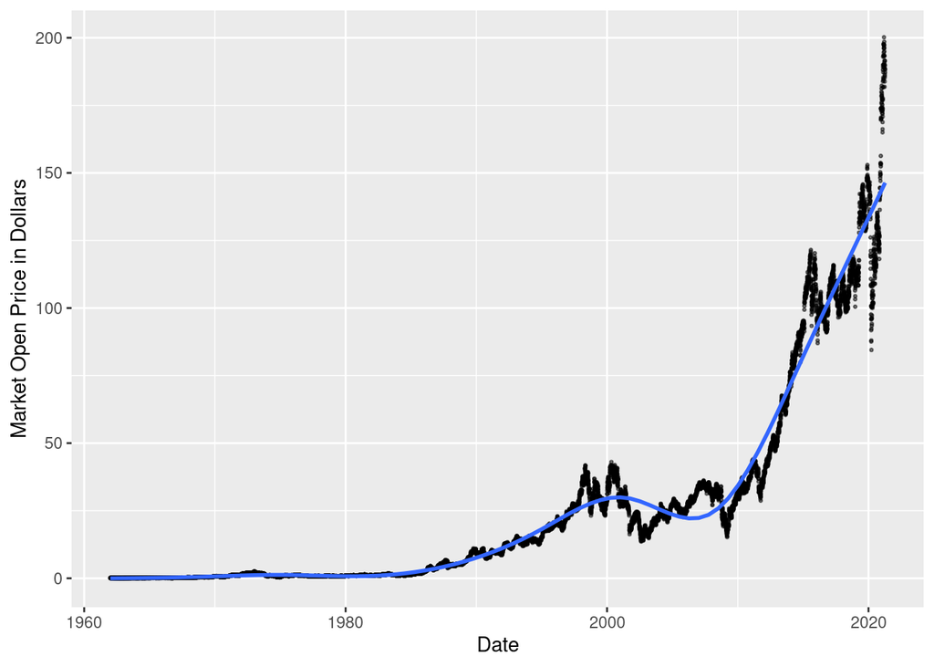

Daily Disney Stock Prices from 1962 to 2021

I added dates for Marvel, Star Wars, Disney Plus, and Disney parks events, as well before merging the movie data frame with the stock data frame. The final data frame is named DisFinal and only includes dates on which a movie was released or a Disney World type event occurred. I also split DisFinal into two more data frames. One is for dates before January 01, 2000 (DisFinalB00) and one is for dates after January 01, 2000 (DisFinalA00). Figures 2 and 3 show graphical summaries for the daily stock data during their respective time periods. Before 2000, the stock price saw exponential growth while after 2000 it still continued to increase but it was more unstable and has its ups and downs.

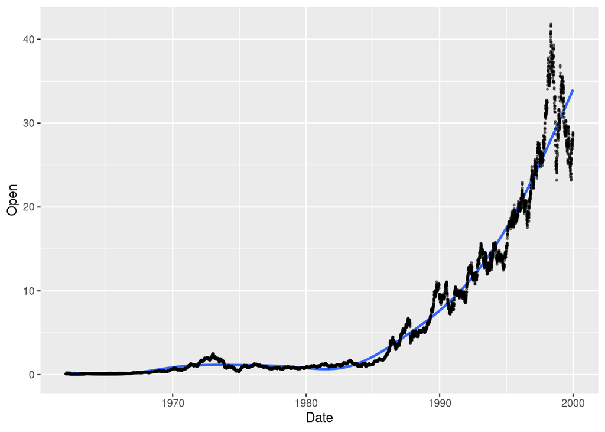

Daily Disney Stock Prices from 1962 to 2000

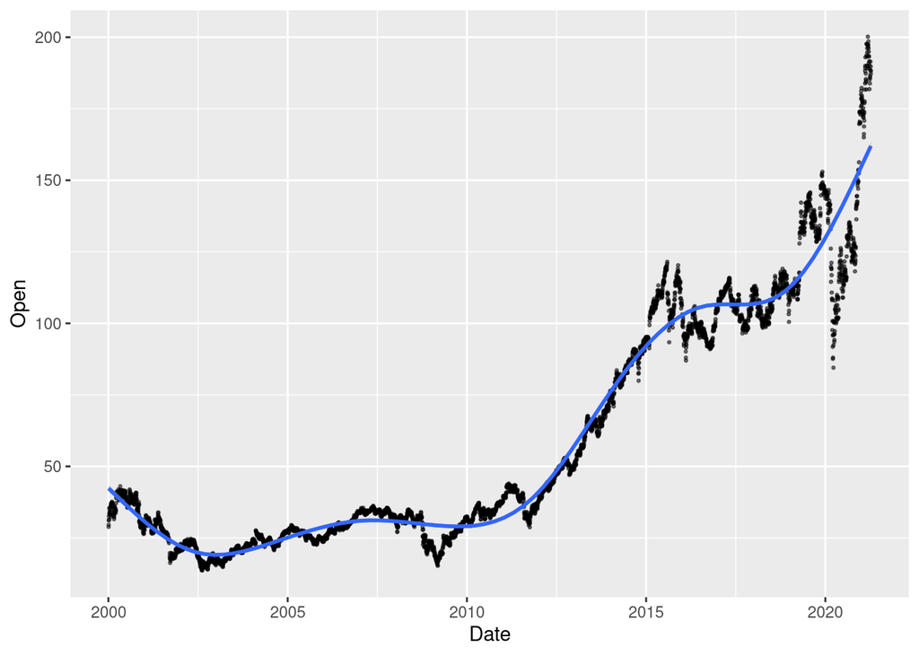

Daily Disney Stock Prices from 2000 to 2021

Since the value of the US dollar was very different in 1962 than it currently is, I had to adjust for this difference by calculating the percent change in stock instead of using the raw change in value. The functions used to make these calculations are included in the appendix. The three variables I created were PC Week Before, PC Week After, and Day Percent Change. PC Week Before contains the percent change in stock price for the week leading up to a movie release, PC Week After contains the percent change for the week after a movie release, and Day Percent Change is the percent change in stock price the day of a movie release.

Numeric summaries can be seen for all three data frames in Tables 2, 3, and 4, where n equals the total number of observations for its particular category. At first glance, I noticed two major summary pieces. The number of observations for live action (217) and animated movies (83) are way higher than the other categories and some of the average percent change in stock values are negative. Star Wars stands out the most with average percent change the week after at -1.597% and average percent change the day of at -1.003%. It can also be noticed that some categories have stock prices that on average increase the week before but decrease the week after. For example animated movie releases had an average stock decrease of -0.890% the week after a release but had a 0.534% increase in the week leading up to a release.

Numeric Summaries By Event Description

| Event Description | Average PC Week After | Average PC Week Before | Average PC Day Of | n |
| --- | --- | --- | --- | --- |
| A | -0.890 | 0.534 | 0.369 | 83 |
| D | 1.923 | -0.925 | 0.786 | 10 |
| DP | 3.737 | 2.717 | -0.269 | 4 |
| DW | -0.453 | 0.652 | 1.007 | 16 |
| H | -0.269 | 0.230 | 0.431 | 8 |
| L | 0.574 | 0.527 | -0.003 | 217 |
| M | 0.399 | 0.851 | 0.116 | 16 |
| N | 3.063 | 2.393 | 0.266 | 13 |
| SW | -1.597 | 0.448 | -1.003 | 6 |

Numeric Summaries for Before 2000 By Event Description

| Event Description | Average PC Week After | Average PC Week Before | Average PC Day Of | n |
| --- | --- | --- | --- | --- |
| A | -1.995 | 0.203 | 0.201 | 25 |
| D | 1.319 | 2.018 | 0.659 | 1 |
| DW | -0.176 | 1.257 | 0.968 | 9 |
| H | 1.753 | -0.723 | 0.559 | 4 |
| L | 0.560 | 0.435 | -0.028 | 132 |
| N | 1.613 | 2.479 | 0.000 | 1 |

Numeric Summaries for After 2000 By Event Description

| Event Description | Average PC Week After | Average PC Week Before | Average PC Day Of | n |
| --- | --- | --- | --- | --- |
| A | -0.413 | 0.677 | 0.442 | 58 |
| D | 1.991 | -1.251 | 0.800 | 9 |
| DP | 3.737 | 2.717 | -0.269 | 4 |
| DW | -0.809 | -0.126 | 1.058 | 7 |
| H | -2.292 | 1.182 | 0.302 | 4 |
| L | 0.596 | 0.669 | 0.037 | 85 |
| M | 0.399 | 0.851 | 0.116 | 16 |
| N | 3.184 | 2.386 | 0.288 | 12 |
| SW | -1.597 | 0.448 | -1.003 | 6 |

## Methods

To determine whether there are significant differences in the short term percent changes of stock prices depending on the type to movie release or Disney parks event, this project uses one-way ANOVA. One-way ANOVA is a method that tests for differences in means. In the case of this analysis, the hypotheses would be as follows:

- $H_{0} = \mu_{A} = \mu_{D} = \mu_{DP} = \mu_{DW} = \mu_{H} = \mu_{L}= \mu_{M} = \mu_{N} = \mu_{SW}$
- $H_{a} = not\ all\ population\ means\ are\ equal$

- $H_{0} = \mu_{B2000} = \mu_{A2000}$
- $H_{a} = \mu_{B2000} \neq \mu_{A2000}$
- $H_{0} = \mu_{WeekA} = \mu_{WeekB}$
- $H_{a} = \mu_{WeekA} \neq \mu_{WeekB}$

The p-value at which a difference is significant is less than 0.05 which is the same as ANOVA.

## Data Analysis/Results

### Comparing Event Descriptions

Before performing the one-way ANOVA tests, I viewed plots for my three percent change response variables. I chose to only include the plot for the percent change in stocks the week after an event since the percent change day of and the percent change week before plots were very similar to it. The percentage values are grouped by the Event Description variable. The code for all of the plots is included in Appendix II.

While examining Figure 4, I noticed there does not seem to be a big difference between any category of movie and the Disney parks events do not behave any differently than the movie releases. The lowest mean is Star Wars releases but its box plot still overlaps with the Disney Plus releases box plot which has the highest mean. All of three of the tested response variables show a similar pattern so before running the ANOVA the results are already pointing to no significance.

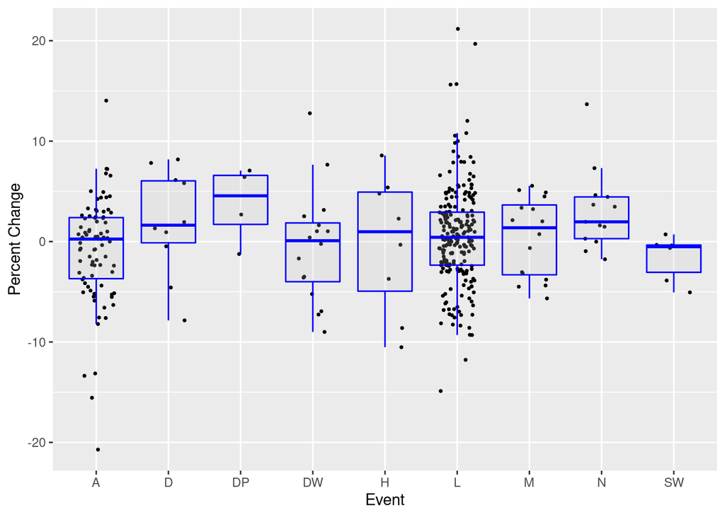

Percent Changes in Stock the Week After an Event Grouped By Event Description

### T-tests

In viewing Figures 5 and 6, it does not appear there is a significant difference between the average stock changes a week after a release before 2000 and after 2000. For both figures, the averages mostly hang around zero just like they do when all the dates are plotted together. Once again, I did not include plots for the other two response variables because they are very similar to the ones I did show, but the code is included in Appendix II.

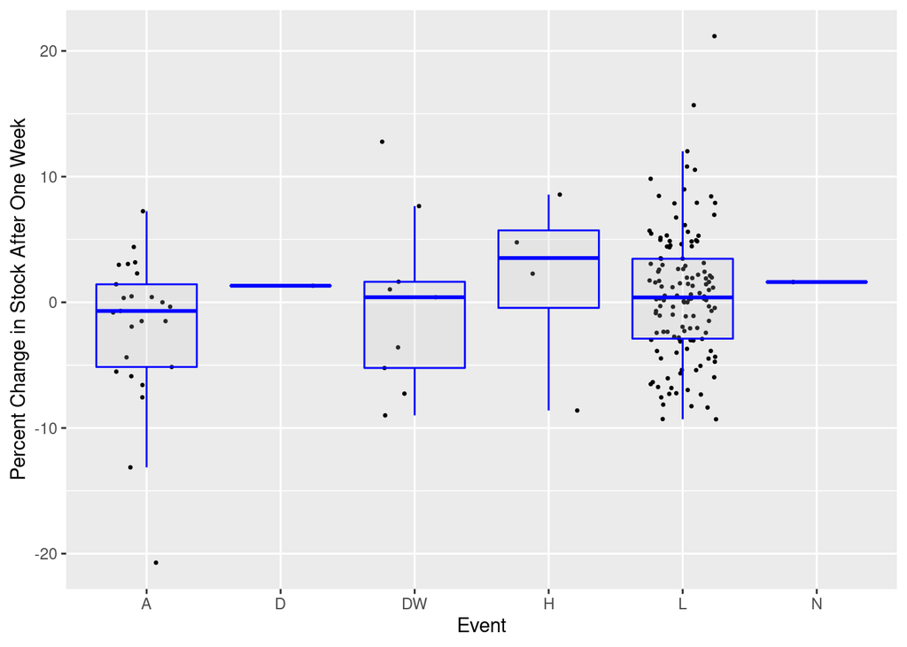

Percent Changes in Stock Prices the Week After an Event or Release Before 2000

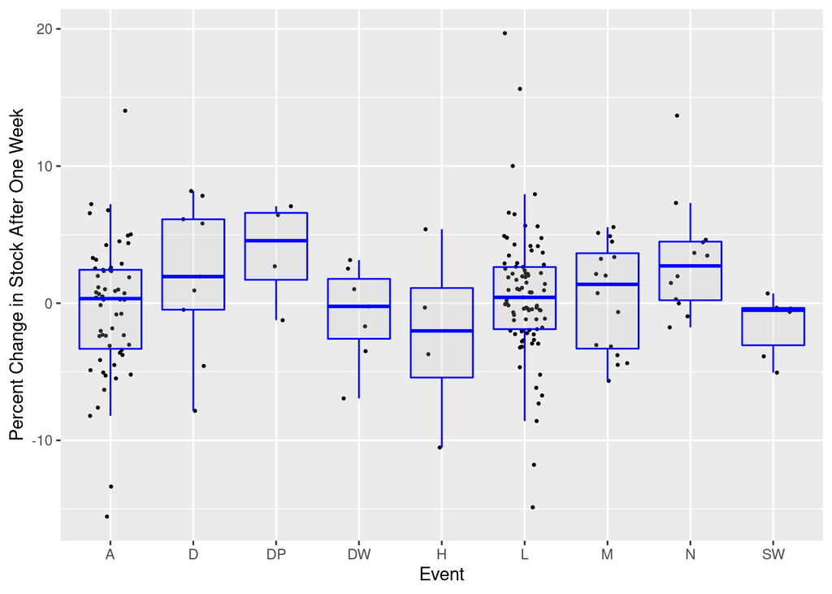

Percent Changes in Stock Prices the Week After an Event or Release After 2000

The hypothesis test for the t-test comparing the percent changes in stock the week after an event vs the week before an event gave a T statistic of 0.811 and a p-value of 0.417. From this we can draw the conclusion that there is no significant different in stock prices the week before vs the week after.

### Percent Change Confidence Intervals

All the confidence intervals except for two, percent change the week before for releases after 2000 (0.113, 1.325) and percent change the week before for all releases (0.115, 1.064), contained the value zero. This means for most of the response variables there is no evidence short term stock prices increase or decrease when movies are released or Disney parks event occur. There are a few intervals that barely contain zero so even though it is not significant, it may be something worth noticing.

## Discussion/Conclusion

This project surprise me right away when I was doing exploratory analysis. What surprise me the most was that particular types of movie categories that I thought would show larger percent increases on average did not and some were even negative averages. In recent years, Marvel has done incredibly well at the box offices and although its average percent increase the week after releases was positive (0.399%), it was not a relatively large increase. The Star Wars franchise is also very popular but its releases showed negative percent stock changes. It was also interesting that for some movie categories, the percent change in the week leading up to a release was higher than the percent change the week after. I cannot think of an explanation for this other than there is nothing to explain. The t-test that tested for this did not give sufficient evidence to say there is a difference.

Using what I discovered, if I were to offer advice to a short term investor who was looking at buying Disney stock, I would tell them basing their decisions on when movies are released and when Disney parks event happen is not an effective method. No particular type of movie release has a more positive effect than any of the others. Long term you can probably expect Disney stock prices to increase but more analysis is needed to determine what influences short term changes.

## Reference Links

[List of Walt Disney Pictures films page on Wikipedia](https://en.wikipedia.org/wiki/List_of_Walt_Disney_Pictures_films)  
[Disney Stock Data](https://finance.yahoo.com/quote/DIS/history)  
[ANOVA Method](https://www.statology.org/one-way-anova/)  
[T-test Method](https://www.educba.com/t-test-formula/)

## Appendicies

### Appendix I: Data Cleaning, Data Organizing, and Variable Creation

```r
PercentChange=function(x){
  row=which(grepl(x,DisComp$Date))
  Opening1=DisComp$Open[DisComp$Date==x]
  week=row+7
  Day7=DisComp$Close[week]
  Percent=((Day7-Opening1)/Opening1)*100
  return(Percent)
}
PercentChange2=function(x){
  row=which(grepl(x,DisComp$Date))
  Opening1=DisComp$Open[DisComp$Date==x]
  week=row-7
  Day7=DisComp$Close[week]
  Percent=((Opening1-Day7)/Day7)*100
  return(Percent)
}
OpenClose=function(x){
  Opening=DisComp$Open[DisComp$Date==x]
  Closing=DisComp$Close[DisComp$Date==x]
  Percent=((Closing-Opening)/Opening)*100
  return(Percent)
}
PercentChange3=function(x){
  row=which(grepl(x,DisComp$Date))
  Opening1=DisComp$Open[DisComp$Date==x]
  week=row+30
  Day7=DisComp$Close[week]
  Percent=((Day7-Opening1)/Opening1)*100
  return(Percent)
}
df=as.data.frame(sapply(DisCompNA$Date,OpenClose))
DisFinal1=cbind(DisCompNA,df)
df2=as.data.frame(sapply(DisCompNA$Date,PercentChange))
DisFinal2=cbind(DisFinal1,df2)
df3=as.data.frame(sapply(DisCompNA$Dat,PercentChange2))
DisFinal=cbind(DisFinal2,df3)
df4=as.data.frame(sapply(DisCompNA$Date,PercentChange3))
DisFinal=cbind(DisFinal,df4)
colnames(DisFinal)=c("Date","Event Description","Title or Event","Open","High","Low","Close","Adj Close","Volume","Day Percent Change","PC Week After","PC Week Before","PC 30 Days After")
DisFinalB00=DisFinal[DisFinal$Date < "2000-01-01",]
DisFinalA00=DisFinal[DisFinal$Date > "2000-01-01",]
```

### Appendix II: Exploratory Analysis

```r
DisFinal %>% summarise("Average PC Week After"=mean(`PC Week After`),
                       "Average PC Week Before"=mean(`PC Week Before`),
                       "Average PC Day Of"=mean(`Day Percent Change`))
DisFinal %>% group_by(`Event Description`) %>%
  dplyr::summarise("Average PC Week After"=mean(`PC Week After`),
            "Average PC Week Before"=mean(`PC Week Before`),
            "Average PC Day Of"=mean(`Day Percent Change`), n=n())
DisFinalB00 %>% summarise("Average PC Week After"=mean(`PC Week After`),
                       "Average PC Week Before"=mean(`PC Week Before`),
                       "Average PC Day Of"=mean(`Day Percent Change`))
DisFinalA00 %>% summarise("Average PC Week After"=mean(`PC Week After`),
                       "Average PC Week Before"=mean(`PC Week Before`),
                       "Average PC Day Of"=mean(`Day Percent Change`))
```

```r
library(ggplot2)
DisPlus=DisFinal$`PC Week After`+ DisFinal$`PC Week Before`

ggplot(data=DisStock, aes(x=Date,y=Open)) +
  geom_point(alpha=0.5,size=0.5) + geom_smooth() + ggtitle("Daily Disney Stock Prices (1962 to 2021)")

ggplot(data=DisStock[DisStock$Date<"2000-01-01",], aes(x=Date,y=Open)) +
  geom_smooth() + geom_point(alpha=0.5,size=0.5)

ggplot(data=DisStock[DisStock$Date>"2000-01-01",], aes(x=Date,y=Open)) +
  geom_point(alpha=0.5,size=0.5) + geom_smooth()

ggplot(data=DisFinal, aes(x = `Event Description`, y = `PC Week After`)) +
  geom_point(position = position_jitter(width = 0.25),size=0.6) +
  geom_boxplot(fill = "grey80", colour = "blue",outlier.colour = NA,alpha=.2) +
  scale_x_discrete() + xlab("Event") +
  ylab("Percent Change") + ggtitle("One Week After the Event")

ggplot(data=DisFinal, aes(x = `Event Description`, y = `PC Week Before`)) +
  geom_point(position = position_jitter(width = 0.25),size=0.5) +
  geom_boxplot(fill = "grey80", colour = "blue",outlier.colour = NA,alpha=.2) +
  scale_x_discrete() + xlab("Event") +
  ylab("Percent Change in Stock the Week Before the Event")

ggplot(data=DisFinal, aes(x = `Event Description`, y = `Day Percent Change`)) +
  geom_point(position = position_jitter(width = 0.25),size=0.5) +
  geom_boxplot(fill = "grey80", colour = "blue",outlier.colour = NA,alpha=.2) +
  scale_x_discrete() + xlab("Event") +
  ylab("Percent Change the Day of the Event")

DisFinal$`Title or Event`[DisFinal$`PC Week After`>10]
```

```r
ggplot(data=DisFinalB00, aes(x = `Event Description`, y = `PC Week After`)) +
  geom_point(position = position_jitter(width = 0.25),size=0.5) +
  geom_boxplot(fill = "grey80", colour = "blue",outlier.colour = NA,alpha=.2) +
  scale_x_discrete() + xlab("Event") +
  ylab("Percent Change in Stock After One Week") +
  ggtitle("Before Jan. 1st, 2000")

ggplot(data=DisFinalA00, aes(x = `Event Description`, y = `PC Week After`)) +
  geom_point(position = position_jitter(width = 0.25),size=0.5) +
  geom_boxplot(fill = "grey80", colour = "blue",outlier.colour = NA,alpha=.2) +
  scale_x_discrete() + xlab("Event") +
  ylab("Percent Change in Stock After One Week") +
  ggtitle("After Jan. 1st, 2000")

ggplot(data=DisFinalB00, aes(x = `Event Description`, y = `PC Week Before`)) +
  geom_point(position = position_jitter(width = 0.25),size=0.5) +
  geom_boxplot(fill = "grey80", colour = "blue",outlier.colour = NA,alpha=.2) +
  scale_x_discrete() + xlab("Event") +
  ylab("Percent Change in Stock the Week Before") +
  ggtitle("Before Jan. 1st, 2000")

ggplot(data=DisFinalA00, aes(x = `Event Description`, y = `PC Week Before`)) +
  geom_point(position = position_jitter(width = 0.25),size=0.5) +
  geom_boxplot(fill = "grey80", colour = "blue",outlier.colour = NA,alpha=.2) +
  scale_x_discrete() + xlab("Event") +
  ylab("Percent Change in Stock the Week Before") +
  ggtitle("After Jan. 1st, 2000")

ggplot(data=DisFinalB00, aes(x = `Event Description`, y = `Day Percent Change`)) +
  geom_point(position = position_jitter(width = 0.25),size=0.5) +
  geom_boxplot(fill = "grey80", colour = "blue",outlier.colour = NA,alpha=.2) +
  scale_x_discrete() + xlab("Event") +
  ylab("Percent Change in Stock the Day Of") +
  ggtitle("Before Jan. 1st, 2000")

ggplot(data=DisFinalA00, aes(x = `Event Description`, y = `Day Percent Change`)) +
  geom_point(position = position_jitter(width = 0.25),size=0.5) +
  geom_boxplot(fill = "grey80", colour = "blue",outlier.colour = NA,alpha=.2) +
  scale_x_discrete() + xlab("Event") +
  ylab("Percent Change in Stock the Day Of") +
  ggtitle("After Jan. 1st, 2000")
```

### Appendix III: Statistical Analysis

```r
library(Rmisc)

# Confidence Intervals
CI(DisFinal$`PC Week After`,ci=0.95)
CI(DisFinal$`PC Week Before`,ci=0.95)
CI(DisFinal$`Day Percent Change`,ci=0.95)
CI(DisFinalA00$`PC Week After`,ci=0.95)
CI(DisFinalA00$`PC Week Before`,ci=0.95)
CI(DisFinalA00$`Day Percent Change`,ci=0.95)
CI(DisFinalB00$`PC Week After`,ci=0.95)
CI(DisFinalB00$`PC Week Before`,ci=0.95)
CI(DisFinalB00$`Day Percent Change`,ci=0.95)

#T-tests
t.test(DisFinalA00$`PC Week After`,DisFinalB00$`PC Week After`,var.equal=TRUE)

t.test(DisFinalA00$`PC Week Before`,DisFinalB00$`PC Week Before`,var.equal=TRUE)

t.test(DisFinalA00$`Day Percent Change`,DisFinalB00$`Day Percent Change`,var.equal=TRUE)

t.test(DisFinal$`PC Week Before`,DisFinal$`PC Week After`,var.equal=TRUE)

#ANOVA for full data set
disaov<-aov(`PC Week After` ~ `Event Description`, data=DisFinal)
summary(disaov)
disaov2<-aov(`PC Week Before` ~ `Event Description`, data=DisFinal)
summary(disaov2)
disaov3<-aov(`Day Percent Change` ~ `Event Description`, data=DisFinal)
summary(disaov3)

#ANOVA for data after 2000
disaov4<-aov(`PC Week After` ~ `Event Description`, data=DisFinalA00)
summary(disaov4)
disaov5<-aov(`PC Week Before` ~ `Event Description`, data=DisFinalA00)
summary(disaov5)
disaov6<-aov(`Day Percent Change` ~ `Event Description`, data=DisFinalA00)
summary(disaov6)

#ANOVA for data before 2000
disaov7<-aov(`PC Week After` ~ `Event Description`, data=DisFinalB00)
summary(disaov7)
disaov8<-aov(`PC Week Before` ~ `Event Description`, data=DisFinalB00)
summary(disaov8)
disaov9<-aov(`Day Percent Change` ~ `Event Description`, data=DisFinalB00)
summary(disaov9)
```